# INLA severe-tail, WQC and Lizard logger assessment

Blocked predictive validation for GBR bleaching mortality

## Main result

The severe-tail learner helps the problem it was designed for, but it is not a universal replacement for the INLA expectation. Under reef-blocked validation, the conservative correction raises mean prediction for observed mortality of at least 50% from 35.9% to 39.2%, while pooled RMSE remains 0.136. The soft gate raises the severe mean to 42.5% and lowers severe-case RMSE from 0.325 to 0.277, but increases ordinary false extremes and pooled RMSE.

When an entire event is held out, every tail correction worsens pooled RMSE. This is a harsh test for a compound driver first strongly expressed in 2024, but remains a real warning. The tail expert should be an event-risk ensemble member rather than a silent replacement for the calibrated INLA mean.

| Validation | Model | RMSE | MAE | Predictive R2 | Severe observed | Severe predicted | Severe RMSE | False extreme rate |
| --- | --- | --- | --- | --- | --- | --- | --- | --- |
| Entire event held out | INLA only | 0.197 | 0.138 | -0.236 | 61.7% | 44.1% | 0.407 | 11.3% |
| New reefs within observed events | INLA only | 0.136 | 0.090 | 0.415 | 61.7% | 35.9% | 0.325 | 3.7% |
| Entire event held out | Conservative tail (0.5 gate) | 0.201 | 0.144 | -0.279 | 61.7% | 45.1% | 0.397 | 13.1% |
| Entire event held out | Soft-gated tail | 0.206 | 0.150 | -0.353 | 61.7% | 46.0% | 0.388 | 15.7% |
| New reefs within observed events | Conservative tail (0.5 gate) | 0.136 | 0.091 | 0.415 | 61.7% | 39.2% | 0.299 | 6.8% |
| New reefs within observed events | Soft-gated tail | 0.140 | 0.095 | 0.376 | 61.7% | 42.5% | 0.277 | 7.8% |

## Lizard-cluster in-water temperatures

The public AIMS daily endpoint provides 2024-event records for Lizard Island and North Direction reef-flat and reef-slope loggers. Linnet has logger deployments only through 2018, so it cannot directly test the 2024 event.

Season-wide means conceal a material January mismatch. Mean logger-minus-NOAA differences over the full record are only -0.04 to +0.07 degrees C, but January means are +0.08 to +0.44 degrees C. The signed January offset integrates to 0.37–1.94 degree-weeks and the positive-only offset to 0.87–2.05 degree-weeks. These are temperature-offset integrals rather than formal extra DHW because the daily differences have not yet been evaluated against each site’s climatological MMM and HotSpot threshold. Nevertheless they show that a local heat mismatch of ecologically meaningful magnitude is plausible and should be tested explicitly for the Lizard cluster.

Using NOAA’s v3.1 MMM and standard 84-day rule changes the interpretation substantially. The reconstructed NOAA series agrees with the official daily DHW peak within 0.18 DHW. Logger-derived peaks imply an uplift of 1.05–5.38 DHW relative to official NOAA across the full November–April bleaching period. The median regional uplift is 3.85 DHW; the mean is 4.82 DHW for flats and 2.25 DHW for slopes. This depth dependence should be retained in any local sensitivity rather than applying the flat value to 9–10 m observations.

| Site | Series | Context | Days | Mean logger minus NOAA (C) | Warm-quartile difference (C) | Maximum 7-day difference (C) |
| --- | --- | --- | --- | --- | --- | --- |
| Lizard Island | LIZFL1 | 5 m reef flat | 193 | 0.05 | 0.03 | 1.03 |
| Lizard Island | LIZSL1 | 10 m reef slope | 210 | 0.04 | 0.02 | 0.84 |
| North Direction Island | NDIRECTIONFL1 | 2 m reef flat | 211 | 0.07 | 0.11 | 0.79 |
| North Direction Island | NDIRECTIONSL1 | 9 m reef slope | 211 | -0.04 | -0.12 | 0.56 |

| Site | Series | Days | January mean logger minus NOAA (C) | Signed offset (degree-weeks) | Positive-only offset (degree-weeks) | Maximum 7-day difference (C) |
| --- | --- | --- | --- | --- | --- | --- |
| Lizard Island | LIZFL1 | 31 | 0.44 | 1.94 | 2.05 | 1.03 |
| Lizard Island | LIZSL1 | 31 | 0.24 | 1.07 | 1.43 | 0.84 |
| North Direction Island | NDIRECTIONFL1 | 31 | 0.36 | 1.61 | 1.72 | 0.79 |
| North Direction Island | NDIRECTIONSL1 | 31 | 0.08 | 0.37 | 0.87 | 0.56 |

| Site | Series | Context | MMM | Logger peak DHW | Official NOAA peak DHW | DHW uplift | Logger peak date |
| --- | --- | --- | --- | --- | --- | --- | --- |
| Lizard Island | LIZFL1 | Reef flat | 28.59 | 10.53 | 6.27 | 4.26 | 2024-03-08 |
| Lizard Island | LIZSL1 | Reef slope | 28.58 | 9.37 | 5.93 | 3.44 | 2024-03-09 |
| North Direction Island | NDIRECTIONFL1 | Reef flat | 28.56 | 11.61 | 6.23 | 5.38 | 2024-03-27 |
| North Direction Island | NDIRECTIONSL1 | Reef slope | 28.56 | 7.28 | 6.23 | 1.05 | 2024-03-08 |

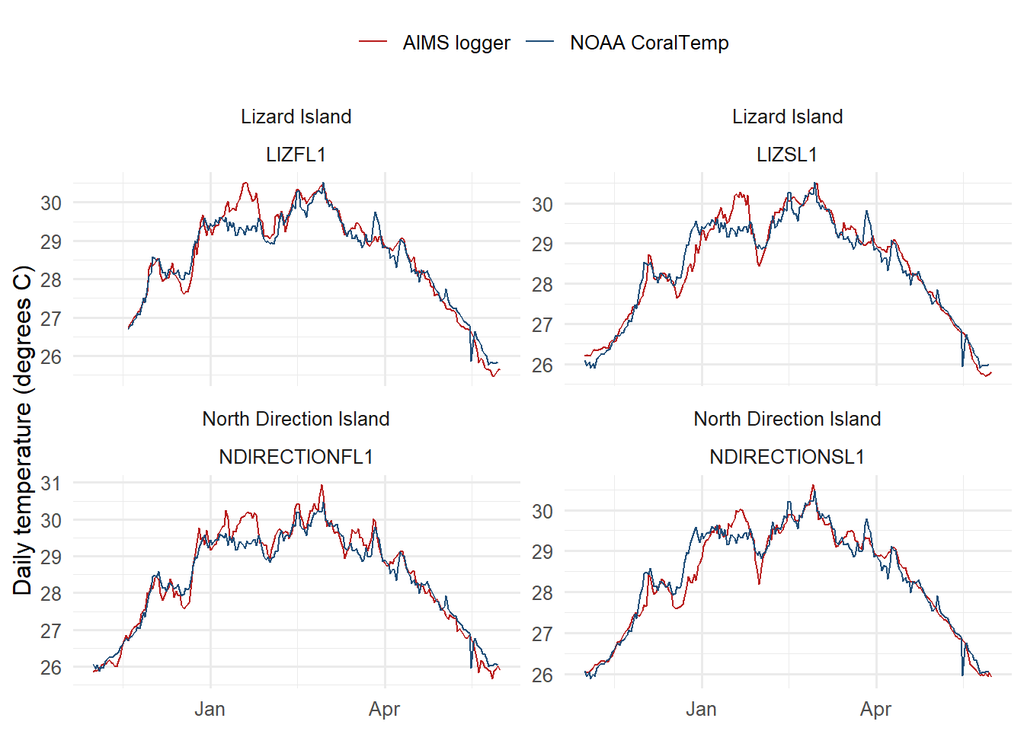

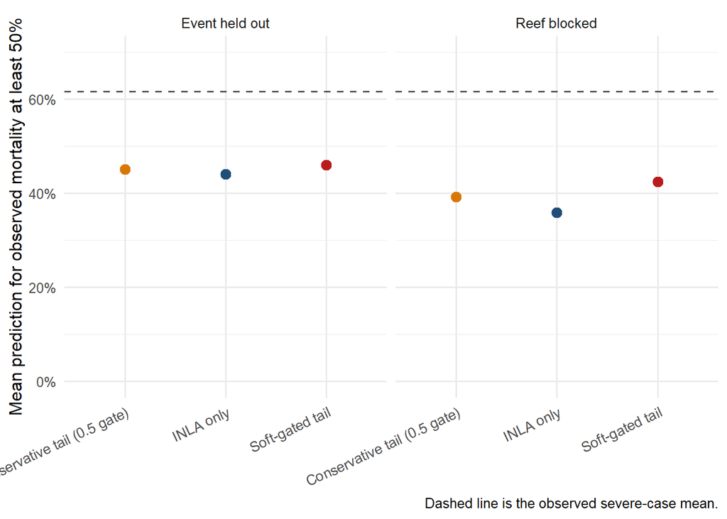

## WQC threshold and cumulative exposure

RRN coloured-water frequency is on a zero-to-one scale, so the apparent breakpoint near 50 in the earlier report is encoded as a hinge above 0.50. The model carries raw WQC, current excess above 0.50, the rolling ten-year sum of annual excess above 0.50, and their DHW interactions.

High WQC observations are enriched for severe mortality: 14 of 76 observations at or above 0.50 have at least 50% mortality, compared with 18 of 461 below 0.50. Raw WQC is influential in the severe gate. However, the threshold and cumulative terms do not improve pooled blocked RMSE over the otherwise identical tail BRT. They remain useful candidates, but the current screen does not establish that the 0.50 hinge alone solves the severe misses.

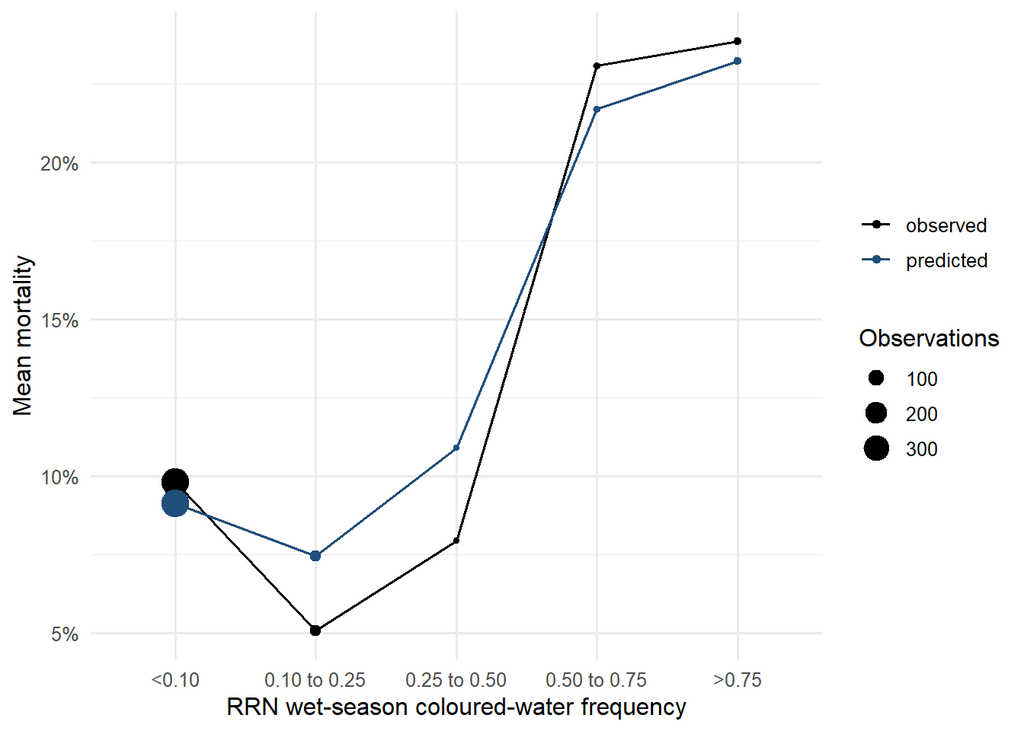

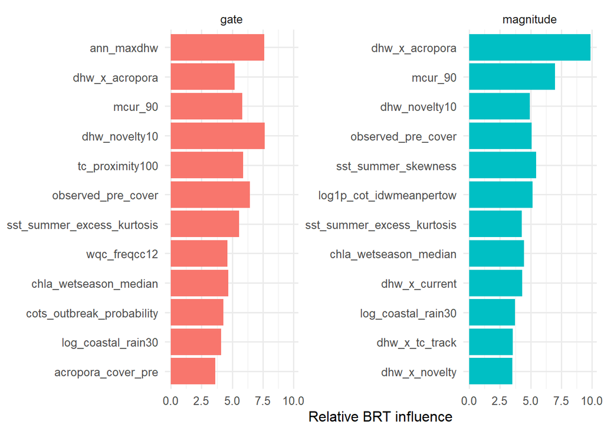

## Cyclone-track and COTS in the central INLA model

Adding provisional cyclone-track proximity, the wind-distance index and the GBR COTS outbreak-probability hindcast improves both principal validation schemes. Reef-blocked RMSE falls from 0.1369 to 0.1357 and predictive R2 rises from 40.5% to 41.5%. Leave-event-out RMSE falls from 0.2008 to 0.1973. The severe-case mean increases from 35.4% to 35.9%. This is a small but consistent gain, so this pressure model is now the central INLA baseline used by the tail BRT. The RRN wave and COTS fields remain in the model; these new variables add track geometry and the independent outbreak hindcast.

| Model | Validation | RMSE | Predictive R2 | Severe predicted | Severe RMSE | False extreme rate | WAIC |
| --- | --- | --- | --- | --- | --- | --- | --- |
| Add cyclone track + COTS | Event held out | 0.197 | -0.236 | 44.1% | 0.407 | 11.3% | 178.9 |
| Also add disease risk | Event held out | 0.211 | -0.419 | 44.5% | 0.398 | 18.3% | 180.3 |
| Previous INLA baseline | Event held out | 0.201 | -0.281 | 42.2% | 0.409 | 12.9% | 176.8 |
| Add cyclone track + COTS | Reef blocked | 0.136 | 0.415 | 35.9% | 0.325 | 3.7% | 178.9 |
| Also add disease risk | Reef blocked | 0.136 | 0.414 | 35.9% | 0.325 | 3.7% | 180.3 |
| Previous INLA baseline | Reef blocked | 0.137 | 0.405 | 35.4% | 0.331 | 4.1% | 176.8 |

| Term | Mean | SD | 2.5% | 97.5% |
| --- | --- | --- | --- | --- |
| Cyclone-track proximity | 0.037 | 0.181 | -0.317 | 0.391 |
| Cyclone wind-distance index | 0.122 | 0.146 | -0.165 | 0.408 |
| COTS outbreak probability | 0.116 | 0.068 | -0.018 | 0.251 |

## NOAA disease-risk screen

The disease product is structurally selective, not a continuous GBR-wide covariate. It is applicable at 23 of 73 validation reef-years in 2020 and only three of 61 in 2022; all validation locations are masked by the product’s winter prerequisite in 2016, 2017 and 2024. Negative mask codes were therefore kept distinct from valid zero risk during extraction.

| year | Reef-years | Applicable | Maximum risk | Days at risk >= 1 (maximum) |
| --- | --- | --- | --- | --- |
| 2016 | 29 | 0 | 0.00 | 0 |
| 2017 | 38 | 0 | 0.00 | 0 |
| 2020 | 73 | 23 | 6.48 | 111 |
| 2022 | 61 | 3 | 0.65 | 0 |
| 2024 | 103 | 0 | 0.00 | 0 |

Adding disease intensity and duration to INLA worsens leave-event-out RMSE from 0.197 to 0.211 and raises the false-extreme rate from 11.3% to 18.3%. Adding the same features and a DHW interaction to the tail BRT also weakens reef-blocked RMSE. The raw disease features receive zero production BRT influence; only their interaction receives small influence. The metric is ecologically relevant for interpreting Gannett Cay and other 2020 residuals, but it is not promoted into the operational ensemble on this evidence.

| Validation | Model | RMSE | Predictive R2 | Severe predicted | Severe RMSE |
| --- | --- | --- | --- | --- | --- |
| Event held out | Tail BRT with disease | 0.201 | -0.279 | 45.0% | 0.398 |
| Event held out | Tail BRT without disease | 0.201 | -0.279 | 45.1% | 0.397 |
| Reef blocked | Tail BRT with disease | 0.136 | 0.409 | 38.7% | 0.301 |
| Reef blocked | Tail BRT without disease | 0.136 | 0.415 | 39.2% | 0.299 |

## 2024 manta-tow severe cases

For 2024 manta tow, the reef-blocked soft WQC-plus-track tail raises the severe mean from 33.1% to 39.3% and lowers RMSE from 0.163 to 0.158. It still falls well short of the observed severe mean of 58.0%.

| Validation | Model | RMSE | Bias | Severe predicted | Severe observed | False extreme rate |
| --- | --- | --- | --- | --- | --- | --- |
| Event held out | INLA only | 0.267 | 0.009 | 36.1% | 58.0% | 23.4% |
| Event held out | Conservative tail (0.5 gate) | 0.266 | 0.011 | 36.4% | 58.0% | 23.4% |
| Event held out | Soft-gated tail | 0.264 | 0.013 | 36.7% | 58.0% | 23.4% |
| Reef blocked | INLA only | 0.163 | -0.036 | 33.1% | 58.0% | 1.6% |
| Reef blocked | Conservative tail (0.5 gate) | 0.158 | -0.021 | 36.2% | 58.0% | 3.1% |
| Reef blocked | Soft-gated tail | 0.158 | -0.006 | 39.3% | 58.0% | 4.7% |

## Cyclone exposure is provisional

The current best-track block uses nearest-track distance, reported maximum wind and a wind-by-distance index alongside RRN hours above 4 m waves. It gives a clear Jasper proximity signal at Mackay and Snapper even where the RRN wave field is weak. These fields are isolated in the fitting script because a better cyclone data set resolving Jasper and Kirrily is expected and should replace this block before the operational fit.

| Reef | Nearest cyclone | Track distance (km) | Nearest max wind (m/s) | Storms within 300 km |
| --- | --- | --- | --- | --- |
| Mackay Reef (16-015) | Jasper | 31.2 | 25.7 | 1 |
| Snapper Island (16-006) | Jasper | 45.4 | 25.7 | 1 |
| Mackay Reefs (15-024) | Jasper | 77.5 | 25.7 | 1 |

## Remaining severe misses

Repeated observations are useful to the likelihood but should not be confused with independent unexplained reef events. Snapper contributes three of the top five observation-level misses. The table below therefore averages predictions within reef, event and programme before ranking; the fit and its inclusion logic are unchanged.

| Programme | Reef | Year | Observations | DHW | Observed | Predicted | Underprediction | WQC | Cyclone distance (km) |
| --- | --- | --- | --- | --- | --- | --- | --- | --- | --- |
| LTMP | Penrith Reef (21-025) | 2017 | 1 | 4.9 | 73.3% | 4.8% | 68.5% | 0.00 | 155 |
| LTMP | Gannett Cay Reef (21-556) | 2020 | 1 | 6.8 | 56.6% | 4.8% | 51.7% | 0.00 | 622 |
| MANTA | Mackay Reef (16-015) | 2024 | 1 | 3.5 | 61.3% | 15.3% | 46.0% | 0.07 | 31 |
| MMP | Snapper Reef (16-006) | 2024 | 4 | 6.9 | 67.4% | 35.0% | 32.3% | 0.90 | 45 |
| MANTA | Linnet Reef (14-126) | 2024 | 1 | 6.7 | 71.5% | 39.2% | 32.3% | 0.54 | 124 |
| LTMP | Opal Reef (16-025) | 2016 | 1 | 5.8 | 58.2% | 31.1% | 27.1% | 0.00 | 861 |
| LTMP | Hastings Reef (16-057) | 2017 | 1 | 10.2 | 63.8% | 39.4% | 24.4% | 0.00 | 490 |
| LTMP | Broomfield Reef (23-048) | 2024 | 1 | 11.6 | 68.8% | 49.9% | 18.9% | 0.04 | 641 |
| MANTA | Broomfield Reef (23-048) | 2024 | 1 | 11.6 | 57.1% | 41.4% | 15.7% | 0.04 | 641 |
| MANTA | Eyrie Reef (14-118) | 2024 | 1 | 6.3 | 52.6% | 37.1% | 15.5% | 0.39 | 129 |
| LTMP | Agincourt Reefs (No 1) (15-099c) | 2016 | 1 | 6.9 | 53.2% | 38.1% | 15.2% | 0.00 | 867 |
| MANTA | Hoskyn Islands Reef (23-080) | 2024 | 1 | 11.2 | 54.8% | 41.3% | 13.5% | 0.05 | 711 |
| MANTA | Feather Reef (17-034) | 2017 | 1 | 8.9 | 50.8% | 38.6% | 12.3% | 0.05 | 379 |
| LTMP | Lady Musgrave Reef (23-082a) | 2024 | 1 | 11.1 | 54.3% | 45.5% | 8.8% | 0.05 | 725 |
| LTMP | Thetford Reef (16-068) | 2017 | 1 | 10.9 | 57.8% | 52.1% | 5.7% | 0.00 | 454 |

## Ecological explanation register

The high-priority misses now have a versioned explanation register. The labels are diagnostic evidence and do not silently remove observations or change the disturbance logic. Gannett Cay is especially informative: its 2020 COTS outbreak probability is 0.934 and the independent RRN IDW COTS estimate is 0.839, so the severe-tail screen now includes the hindcast probability as well as the RRN pressure.

| Reef | Year | Likely explanation | Evidence status | Current signal | Next model action |
| --- | --- | --- | --- | --- | --- |
| Snapper Reef | 2024 | Jasper flooding and freshwater exposure | high confidence from multiple ecological evidence lines | 3 of top 5 raw misses; WQC=0.897; Jasper track distance=45.4 km; RRN wave hours=0 | retain WQC and cyclone proximity then replace provisional cyclone layer |
| Penrith Reef | 2017 | storm damage associated with Cyclone Debbie | high confidence from LTMP note plus RRN pressure | RRN damaging wave exposure=34.85 hours | retain RRN wave hours until improved cyclone layer arrives |
| Gannett Cay Reef | 2020 | COTS loss | high confidence from two independent gridded COTS signals | COTS outbreak hindcast=0.934; RRN IDW COTS=0.8393 | include COTS outbreak hindcast and compare against RRN COTS pressure |
| Mackay Reef | 2024 | Jasper freshwater and cyclone impact | high ecological confidence but current RRN layers miss the process | RRN WQC=0.067; RRN wave hours=0 | retain provisional track proximity and replace it with forthcoming cyclone layer |
| Linnet Reef | 2024 | local heat mismatch plus possible rainfall mortality and COTS effects | mixed evidence; regional logger signal supports heat mismatch but Linnet has no 2024 logger | WQC=0.537; COTS hindcast=0.029; RRN IDW COTS=0.0201 | test regional logger-calibrated heat sensitivity and retain documented COTS pressure |
| Opal Reef | 2016 | uncertain preceding-cover estimate | data-quality hypothesis with large reported uncertainty | preceding estimate reported to have wide error bars | propagate cover uncertainty or sensitivity-test the observation |
| Tobias Spit | 2024 | 2 m survey data affected by Jasper floodwaters | high contextual confidence from survey notes; incomplete predictor representation | WQC=0.749; RRN wave hours=0 | retain freshwater proxy and replace provisional cyclone layer |

## Operational decision

1. Use the partially pooled cyclone-track plus COTS INLA as the calibrated central estimate; retain the previous baseline as an ablation.
2. Carry the conservative tail BRT as an ensemble member for within-event GBR mapping; expose the soft gate as a high-risk scenario.
3. Retain raw WQC, the 0.50 hinge and cumulative exposure, without yet claiming a validated threshold mechanism.
4. Replace the provisional cyclone block with the forthcoming Jasper/Kirrily-resolving data, then repeat the unchanged blocked comparison.
5. Do not apply a blanket DHW uplift near Lizard. Instead calculate a logger-consistent HotSpot/DHW diagnostic using the local MMM; the January offset is large enough to test as a candidate explanation.
6. Maintain the reef-event explanation register and expose both observation- level and reef-event-level miss rankings in formal validation.
7. Retain NOAA disease risk for ecological attribution and sensitivity plots, but do not include it in the operational ensemble unless new validation shows stable gains.